# Goltz, Till, and Kent (2024) Calculation of Flux

## Summary

This notebook will allow you to calculate flux given appropriate ranges of input variables.

As is, the notebook is tailored to calculate flux per km arc in the Aleutians, but all variables can be changed as desired.

## Load Appropriate Libraries

```r
library(tidyverse) # Imports ggplot (for creation of figures) and dplyr for future data manipulation
library(readxl) # Allows us to read in Excel sheets
library(egg) # Aesthetic package, allows for beautiful and easy formatting, especially of composite figures
library(pracma) # Practical math functions, used here for easy conversion of degrees to radians
```

## Decide on a number of model iterations

For this version, I'm choosing 100000

```r
nrun<-100000
```

## Define Inputs

In the following chunk, we define ranges of input variables. The inputs are in the form Input_range=c(min,max)

```r
# Wet and dry melt fractions
Fwet_range=c(5, 30)
Fdry_range=c(1,20)
# define convergence rate in m/year for the Aleutians
ConvergenceRate_range=c(2e-2,7.5e-2)
# mantle and liquid densities in kg/m3
rhomantle_range=c(3.2e3, 3.3e3)
rhototal_range=c(2.19e3,3.03e3) # liquid range
# Mantle Grain size (in m)
dtotal_range=c(1e-3,10e-3)
# Mantle viscosity (in Pa s)
mu_range=c(1, 10)
# slab dip (in degrees) for the Aleutians
dip_range=c(45.6, 55.9)
# LAB depth (in m) for the Aleutians
depthLAB_range=c(35.6e3,41.4e3)
#Radius ARC-PERPENDICULAR (in m)
volcanoradius_range=c(0.01e3,100e3)
# the radius along the arc in meters. In this example, we're looking to model a flux per km along arc, so this is set stagnant at 0.5km
AlongArcRad_range=c(0.5e3,0.5e3)
# define a range of potential channel radii (define in m).
# the values chosen here are the range of values tested by Grove et al 2002 in their analysis
# and workup of lavas at Mount Shasta. The paper evaluates the viability of Stokes flow for the transport
# of hydrous melts at subduction zones, and, based on the velocity of the mantle, finds an upper limit
# of channel radius. That doesn't really apply to us, since we're only modeling stokes flow for decompression melts
# but we're going to call their tested range reasonable.
channelradius_range=c(0.5e3, 5e3)
#also need gravity (in m/s2)
g<-9.8
```

## Calculate random values to express error around lines

```r
# Let's start with depth the the slab, H
# We will calculate a value of H based on the line of form a*cos(lambda)+b=H, and add to that a random number
# from a normal distribution with mean of zero (or really the mean of the residuals, which is on the order of 1e-16) and s.d. of the r.s.e.
Hcorrection<-rnorm(nrun,mean=3.95e-16,sd=23.62)
# let's define the fit coefficients as rnorm distributions, with nrun number of values
# Start with H from cos dip
Hslope<-41.745
# it did!
Hintercept<-59.072
# now, time from F
tcorrectwet<-rnorm(nrun,mean=2.9e-15,sd=48.77) # we are doing this correction separately for wet and dry melts
tcorrectdry<-rnorm(nrun,mean=2.9e-15,sd=48.77)
tslope=-4.407
tintercept=153.670
# finally, permeability is calculated by a power function fit, involving grain size and F
# it has 2 coefficients, n (basically describes melt connectivity) and C (a geometric constant)
# C has asymmetric error, which we have no way to express in r (to my knowledge)
# instead, we'll approximate it as a normal distribution with standard deviation equal to the average of the two errors
nfitrand<-rnorm(nrun,mean=2.6,sd=0.2)
Cfitrand<-rnorm(nrun,mean=58,sd=29)
# Correction for the upper limit of wet melting, based on range in depth to hottest part of mantle from the syracuse 2010 compilation, which we calculate from H
# Given in m
HMDIntercept<-1.837e4
HMDSlope<-6.656e-1
HMDCorrect<-rnorm(nrun,mean=-5.16184e-13,sd=11600)
```

## Calculate Flux

If using a PC, disable final line 241 of code (i.e., add hash). This function is 100% aesthetic, so you won't miss out on a thing!

```r
#initialize progress bar
pb=txtProgressBar(min = 0, max = nrun, initial = 0, style=3)
for(i in 1:nrun){
  #update progress bar
  setTxtProgressBar(pb,i)
  # first, we will define all random variables from their ranges
  Fwet=(min(Fwet_range)+((max(Fwet_range)-min(Fwet_range)))*nrA)
  Fdry=(min(Fdry_range)+((max(Fdry_range)-min(Fdry_range)))*nrI)
  rhomantle=(min(rhomantle_range)+((max(rhomantle_range)-min(rhomantle_range)))*nrB)
  rhototal=(min(rhototal_range)+((max(rhototal_range)-min(rhototal_range)))*nrC)
  dtotal=(min(dtotal_range)+((max(dtotal_range)-min(dtotal_range)))*nrD)
  mu=(min(mu_range)+((max(mu_range)-min(mu_range)))*nrE)
  dip=(min(dip_range)+((max(dip_range)-min(dip_range)))*nrF)
  depthLAB=(min(depthLAB_range)+((max(depthLAB_range)-min(depthLAB_range)))*nrG)
  volcanoradius=(min(volcanoradius_range)+((max(volcanoradius_range)-min(volcanoradius_range)))*nrH)
  channelradius=(min(channelradius_range)+((max(channelradius_range)-min(channelradius_range)))*nrJ)
  ConvergenceRate=(min(ConvergenceRate_range)+((max(ConvergenceRate_range)-min(ConvergenceRate_range)))*nrK)
  AlongArcRad=(min(AlongArcRad_range)+((max(AlongArcRad_range)-min(AlongArcRad_range)))*nrM)


  # Step 1: Calculate time and scale for grain size
  experimenttimehourwet=((Fwet*tslope)+tintercept)+tcorrectwet
  experimenttimehourwet=ifelse(experimenttimehourwet<0,NA,experimenttimehourwet)
  experimenttimesecondwet=experimenttimehourwet*60*60
  ordermagdiff=1/(1e-6/dtotal) #we assume experimental grain size is on the order of 10-7
  timesecondwet=(experimenttimesecondwet*ordermagdiff^2) # we're scaling by ^2 because of diffusion principles
  timemyrwet=(experimenttimesecondwet*ordermagdiff^2)*3.2e-14

  experimenttimehourdry=((Fdry*tslope)+tintercept)+tcorrectdry
  experimenttimehourdry=ifelse(experimenttimehourdry<0,NA,experimenttimehourdry)
  experimenttimeseconddry=experimenttimehourdry*60*60
  timeseconddry=(experimenttimeseconddry*ordermagdiff^2)
  timemyrdry=(experimenttimeseconddry*ordermagdiff^2)*3.2e-14


  # Step 2: Calculate volume of mantle that is melting
    # Intermediate step: calculate depth to slab (H) given dips in m
    H=((((Hslope*1/cos(dip*pi/180))+Hintercept))+Hcorrection)*10^3 # ok we calculate H from the dip, then we add the correction based on the residual standard error. Then convert to meters.
    H=ifelse(H<0,NA,H)
    # Calculate Hot Mantle Depth from H
    HotMantleDepth=(H*HMDSlope)+HMDIntercept+HMDCorrect # this is the formula as defined above with a correction factor
    #Intermediate step2: discount the mantle not hot enough to melt and lithosphere by subtracting DEPTH OF HOTTEST PART OF MANTLE from H
    Heff=H-HotMantleDepth
    Heff=ifelse(Heff<0,NA,Heff)
  #Calculate height of decompression melting mantle
    Hdry=HotMantleDepth-depthLAB
    Hdry=ifelse(Hdry<0,NA,Hdry)
    # Define Volcano Radius based on Heff. The volcano radius in an iteration CANNOT be greater than the distance to the slab
volcanoradius=(min(volcanoradius_range)+((Heff/tan(dip*pi/180))-min(volcanoradius_range))*nrH)


    # Calculate volume of dry melting mantle (a cylinder). Its arc perpendicular radius is half that Wet Melt, but along arc is the same
    rdry=volcanoradius/2
    volumedry=pi*(rdry)*AlongArcRad*Hdry
  # Calculate volume of wet melting mantle
    #The geometric constraint on the maximum height puts a limit on the allowable radius for a given iteration
    # We're going to use basic geometry to get there. Ultimately we need to define the maximum radius allowed
    # We'll eventually solve for this using the pythagorean theorum but first to do that, we need to define the
    # length of the slab (our hypotenuse) based on the height of the triangle
    SlabLength=Heff/sin(dip*(pi/180))
    # Now we can define the maximum allowable radius as RMax
    RMax=sqrt(SlabLength^2-Heff^2)
    # Define a variable comparing RMax to volcano radius, so we can easily tell the code which runs to disregard
    RCompare=volcanoradius-RMax
    #ok, calculating volume of wet melting
    #Depth of the greatest depth of possible melting Hwet
    Hwet=2*volcanoradius*tan(dip*pi/180)
    # Depth of the point the cylinder intersects the slab, Hcyl. Above this depth, we calculate volume as a standard cylinder
    Hcyl=(RMax-volcanoradius)*tan(dip*pi/180)
    # Depth to the actual depth of wet melting, given a radius less than the Max
    Hwedge=Hwet-Hcyl
    # Volume of the upper cylinder
    VolumeCyl=pi*volcanoradius*AlongArcRad*Hcyl
    #Volume of the wedge, which is a bisected cylinder
    VolumeWedge=pi/2*volcanoradius*AlongArcRad*Hwedge
    volumewet=VolumeCyl+VolumeWedge



  # Step 3: calculate darcy flux and stokes flux
    # let's start with Darcy flux
    # Intermediate step 1: calculate permeability using equation from Miller et al 2014
    k=(((Fwet/100)^nfitrand)*dtotal^2)/Cfitrand
    k=ifelse(k<0,NA,k)
    deltarho=rhomantle-rhototal
    Darcyflux=((k*deltarho*g)/((Fwet/100)*mu)) # this is a darcy velocity
    DarcyTime=(1/Darcyflux*(HotMantleDepth-depthLAB))*3.2e-14 # calculate the amount of time in million years it takes for melt to make it to the crust traveling by Reactive Porous Flow from hot mantle depth
    Stokesflux=((2*deltarho*g*rdry^2)/(9*mu)) #  this is a stokes velocity
    StokesTime=(1/Stokesflux*Hdry)*3.2e-14 # calculate the amount of time in million years it takes for melt to get through the entire cylinder of dry melting via channelized flow

    # Step 4: Calculate extraction efficiency
    WetDiffusionRate=((2.17721E-19)*15)/dtotal # equation based off of that given in Hauri 1997, diffusivity times a porous flow coefficient divided by grain size. Diffusivity from Costa and Chakraborty (2008), T=1300
    Wetefficiency=Darcyflux/WetDiffusionRate
    Wetefficiency=ifelse(Wetefficiency>1,1,Wetefficiency)
    DryDiffusionRate=((2.17721E-19)*10)/channelradius # equation again from Hauri 1997, diffusivity times a channelized flow coefficient, divided by channel radius.
    Dryefficiency=Stokesflux/DryDiffusionRate
    Dryefficiency=ifelse(Dryefficiency>1,1,Dryefficiency)


    # Step 5: Calculate flux in km3/myr
    WetFlux=((Fwet/100)/(timemyrwet+DarcyTime))*(volumewet*1e-9)*Wetefficiency #add to time the darcy and stokes transits
    DryFlux=((Fdry/100)/(timemyrdry+StokesTime))*(volumedry*1e-9)*Dryefficiency
    TotalFlux=WetFlux+DryFlux

    # Step 5.5: Adjust flux for convergence rate
    # Assume that model time/(convergence rate*maximum slab depth) gives the number of times the mantle is replenished and melting can occur
    # We'll use the time from wet melting because it will always be longer
    FluxAdjustWet=(timemyrwet*1e6)/((1/ConvergenceRate)*sqrt(Hwet^2+(2*volcanoradius)^2))# the distance traveled is  a function of the radius as well
    FluxAdjustDry=(timemyrdry*1e6)/((1/ConvergenceRate)*sqrt(Hwet^2+(2*volcanoradius)^2)) # We're just still keeping the depth of the slab
    AdjustedFlux=(WetFlux*FluxAdjustWet)+(DryFlux*FluxAdjustDry)
    #close progress bar
    close(pb)
    if(i==nrun){system("say Get off your ass!")}
}
```

## Create dataframes from raw output

This allows us to plot them more easily later

```r
AdjustedFluxdf<-as.data.frame(AdjustedFlux)
Residualabsdf<-as.data.frame(Residualabs)
TotalFluxdf<-as.data.frame(TotalFlux)
DryFluxdf<-as.data.frame(DryFlux)
WetFluxdf<-as.data.frame(WetFlux)
Dryefficiencydf<-as.data.frame(Dryefficiency)
Wetefficiencydf<-as.data.frame(Wetefficiency)
Stokesfluxdf<-as.data.frame(Stokesflux)
Darcyfluxdf<-as.data.frame(Darcyflux)
deltarhodf<-as.data.frame(deltarho)
kdf<-as.data.frame(k)
volumewetdf<-as.data.frame(volumewet)
volumedrydf<-as.data.frame(volumedry)
Hwetdf<-as.data.frame(Hwet)
Hdrydf<-as.data.frame(Hdry)
Heffdf<-as.data.frame(Heff)
Hdf<-as.data.frame(H)
Fwetdf<-as.data.frame(Fwet)
Fdrydf<-as.data.frame(Fdry)
rhomantledf<-as.data.frame(rhomantle)
rhototaldf<-as.data.frame(rhototal)
dtotaldf<-as.data.frame(dtotal)
mudf<-as.data.frame(mu)
dipdf<-as.data.frame(dip)
depthLABdf<-as.data.frame(depthLAB)
volcanoradiusdf<-as.data.frame(volcanoradius)
experimenttimehourwetdf<-as.data.frame(experimenttimehourwet)
experimenttimesecondwet<-as.data.frame(experimenttimesecondwet)
ordermagdiffdf<-as.data.frame(ordermagdiff)
timesecondwetdf<-as.data.frame(timesecondwet)
timemyrwetdf<-as.data.frame(timemyrwet)
experimenttimehourdrydf<-as.data.frame(experimenttimehourdry)
experimenttimeseconddrydf<-as.data.frame(experimenttimeseconddry)
timeseconddrydf<-as.data.frame(timeseconddry)
timemyrdrydf<-as.data.frame(timemyrdry)
RMaxdf<-as.data.frame(RMax)
RComparedf<-as.data.frame(RCompare)
AlongArcRaddf<-as.data.frame(AlongArcRad)
ConvergenceRatedf<-as.data.frame(ConvergenceRate)
DarcyTimedf<-as.data.frame(DarcyTime)
StokesTimedf<-as.data.frame(StokesTime)
FluxAdjustWetdf<-as.data.frame(FluxAdjustWet)
FluxAdjustDrydf<-as.data.frame(FluxAdjustDry)
```

## Create a big ole dataframe

This one's called AleutiansTest

```r
AleutiansTest<-bind_cols(TotalFluxdf,
                       DryFluxdf,
                       WetFluxdf,
                       Dryefficiencydf,
                       Wetefficiencydf,
                       Stokesfluxdf,
                       Darcyfluxdf,
                       deltarhodf,
                        kdf,
                        volumewetdf,
                        volumedrydf,
                        Hwetdf,
                        Hdrydf,
                        Heffdf,
                        Hdf,
                        Fwetdf,
                        Fdrydf,
                        rhomantledf,
                        rhototaldf,
                        dtotaldf,
                        mudf,
                        dipdf,
                        depthLABdf,
                        volcanoradiusdf,
                        experimenttimehourwetdf,
                        experimenttimesecondwet,
                        ordermagdiffdf,
                        timesecondwetdf,
                        timemyrwetdf,
                        experimenttimehourdrydf,
                        experimenttimeseconddrydf,
                        timeseconddrydf,
                        timemyrdrydf,
                        AdjustedFluxdf,
                        ConvergenceRatedf,
                        RMaxdf,
                        RComparedf,
                        AlongArcRaddf,
                        DarcyTimedf,
                        StokesTimedf,
                       FluxAdjustWetdf,
                       FluxAdjustDrydf)%>%
  mutate(DescentRate=ConvergenceRate*sin(deg2rad(dip)))%>%
  filter(RCompare<=0)
```

We can summarize our results as reported in Table 2:

```r
AverageVolcanicAleutians=211 # From Jicha and Jagoutz (2015)
SummarizeAleutiansTest<-AleutiansTest%>% # define a summary DF
  filter(AdjustedFlux!="NA"&volcanoradius!="NA")%>% # Just checking that we don't have any negative numbers!
  summarize(FML=mean(AdjustedFlux,na.rm=TRUE), # mean flux, or "most likely"
            FSD=sd(AdjustedFlux,na.rm=TRUE))%>%  # standard deviation of the mean
  mutate(FLUB=FML+FSD) # Likely upper bound of flux (mean+sd)
SummarizeAleutiansTest
```

```
       FML      FSD     FLUB
1 150.4079 91.18846 241.5963
```

# Making figures as found in this text

## Figure 2

First, import files (must saved be in same directory as this notebook or, if not, paste in path)

Import simplified data for plotting (simplified table 2)

Generate figure

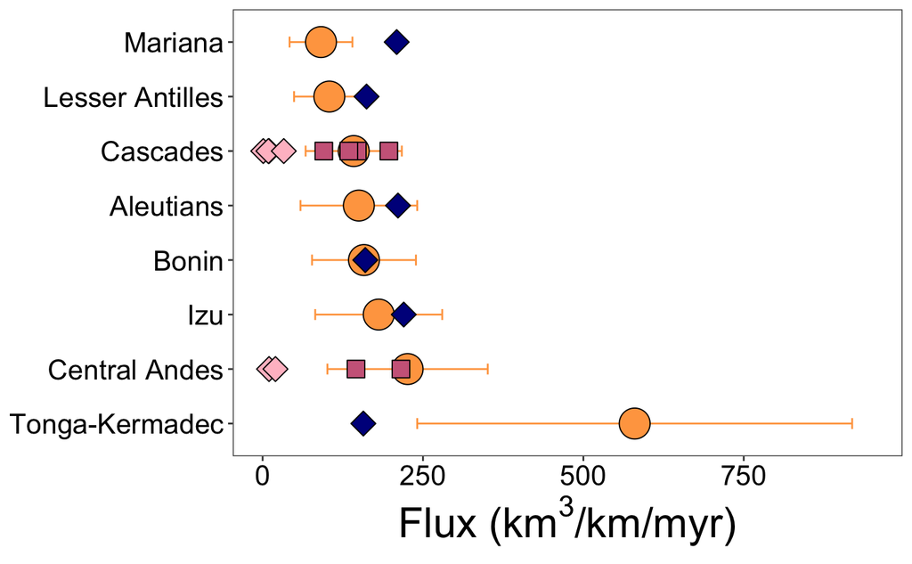

## Supplementary Figure 1

Import dataset of melting experiments and manipulate to calculate F (vol%) Requires file called "MeltingExperiments.xlsx" to be in the directory

OK, let's tidy this up a little

Now let's exclude some experiments we don't want included (see supplementary information for details) and define a dataset with melting volume between 1 and 30 %

Let's generate the plots

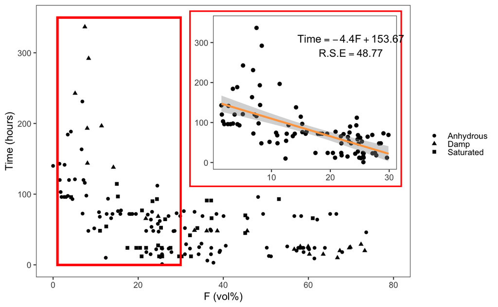

## Supplementary Figure 2

The original version of this plot was generated using a full range of global values, but we can demonstrate the same idea using the same exact dataframe that we made for the Aleutians above (but with 100k runs). In this example, we're having points within 10% of the mean value of flux as defined by Jicha and Jagoutz (2015) plot in black.

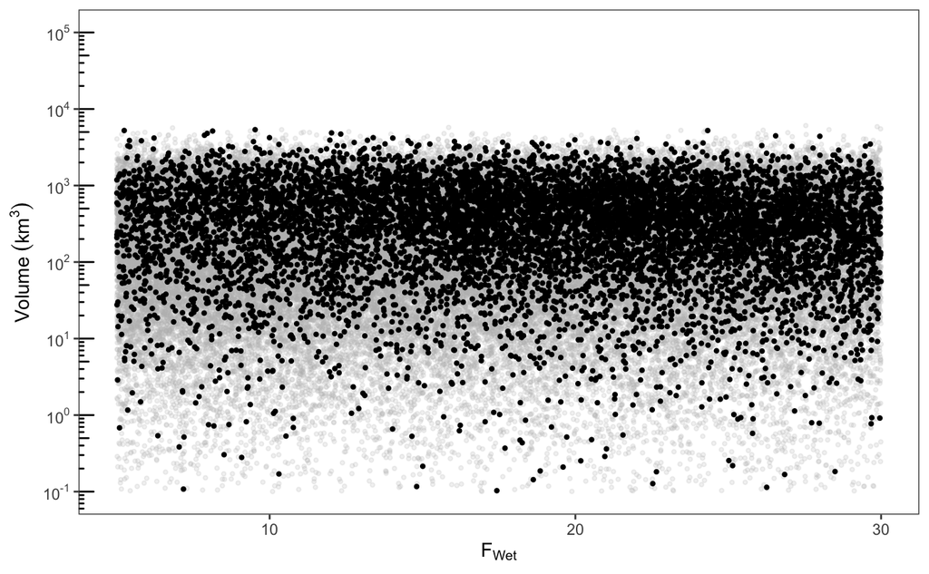

## Supplementary Figure 3

Import dataset with correlation coefficients (as in Table 1)

Generate figure (everything but the arrow)

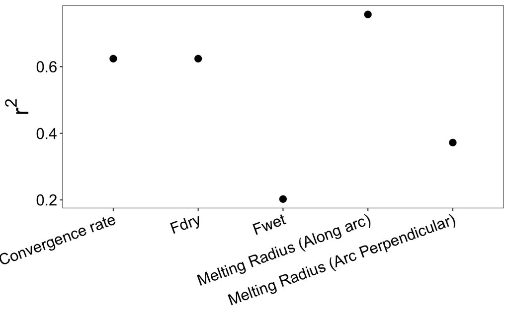